# Sinorhizobium Plasmids Clustering

jp2992

2025-10-06

In this document I present the comparison about the clustering of plasmids of Sinorhizobium using only the ones available in the PLSDB and using the plasmids in the PLSDB plus the putative plasmids retrieved from the collaborator at Penn State University (HiFi).

## Plasmid Redundancy Filtering (MMSeqs2)

### Rationale

> Collaborator’s plasmids were predicted using **RFPlasmid** trained on *Sinorhizobium meliloti*. To ensure a non-redundant set for downstream analysis, we applied a strict filtering step using MMSeqs2. However, both cases are presented (before and after redundancy filtering).

### Filtering Criteria and Command

Redundant sequences were removed using the following conservative thresholds, where coverage applies to both sequences:

- **Coverage:** $\ge 95\%$
- **Sequence Identity:** $\ge 99\%$

```
mmseqs easy-cluster -s 7.5  -c 0.95 --min-seq-id 0.99 predicted_pls.fasta redundant_predicted_pls tmp
```

### Filter Results

| file | format | type | num_seqs | sum_len | min_len | avg_len | max_len |
| --- | --- | --- | --- | --- | --- | --- | --- |
| predicted_pls.fasta | FASTA | DNA | **213** | 34334785 | 48218 | 161196.2 | 338440 |
| redundant_predicted_pls_rep_seq.fasta | FASTA | DNA | **148** | 25067583 | 48218 | 169375.6 | 338440 |

## Clustring Plasmids in Sinorhizobium

Plasmid sequences were clustered using MGE-Cluster.

We can observed the clustering *before* and *after* including the Collaborator data as well as a tab with all the parameters tested to cluster the plasmids. As the purpose is to conserve high level of local similarity a Perplexity between 5-10 and min_cluster of 3 is my preference. However, higher values can help us visualize the stability, for example, of the new cluster formed by the new plasmids.

The new plasmids represented an increment in data as well as in diversity. We can observe some new clusters formed only with the new plasmids.

### All Clusters

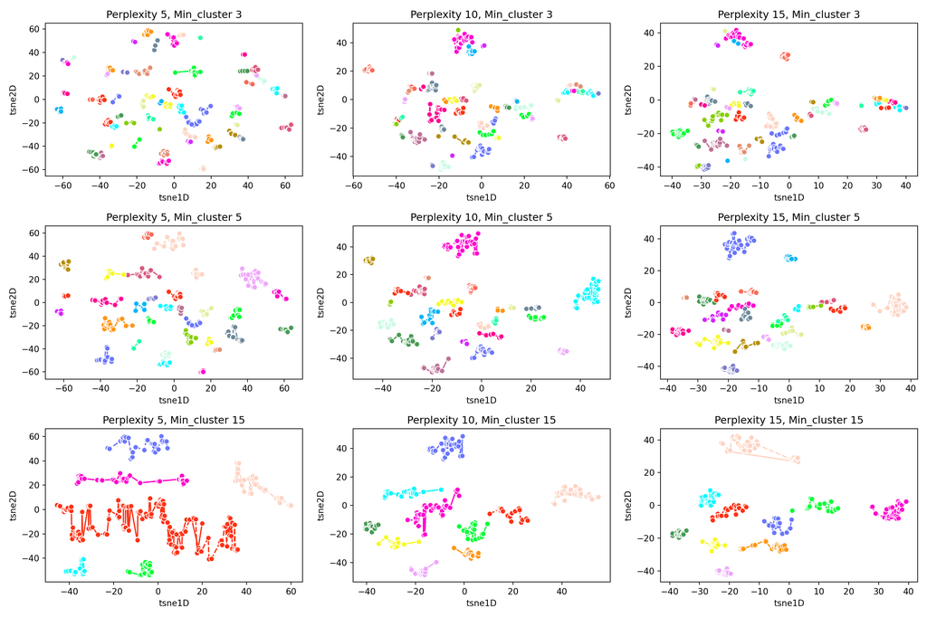

```python
import sys
import os
sys.path.append(os.path.abspath("/n/projects/jp2992/MOLNG4331/code/"))
from utils import parse_multiple_mge_output,scatterplot_multiple_mge_output


perplexity_targets=[5,10,15]
min_cluster_targets=[3,5,15]
path_to_mgemodels="/n/projects/jp2992/MOLNG4331/plasmids_smeliloti/plasmidome/clustering_collab_pls_w_sinorhizobium_plsdb_no_redundant"
mge_all_trial_df=parse_multiple_mge_output(path_to_mgemodels,perplexity_targets,min_cluster_targets)
scatterplot_multiple_mge_output(mge_all_trial_df,perplexity_targets,min_cluster_targets)
```

### Before New plasmids

Clustering using **only** the Sinorhizobium plasmids from the PLSDB.

- Top graph presents the clusters colored by Genus
- Bottom graph represents the clusters colored by the unique clusters established by MGE-Cluster. Colors might be repeated due to the amount of clusters.

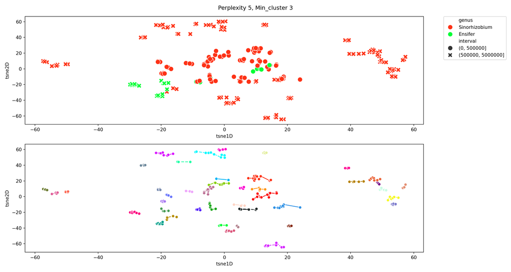

```python
from utils import parse_single_mge_output

perplexity=5
min_cluster=3
mge_output_to_parse=f"/n/projects/jp2992/MOLNG4331/plasmids_smeliloti/plasmidome/clustering_sinorhizobium/mge_out_{perplexity}_{min_cluster}/{perplexity}_{min_cluster}_model_results.csv"
mge_one_trial_df=parse_single_mge_output(mge_output_to_parse,perplexity,min_cluster)

# Scatter Plot
fig,ax=plt.subplots(2,1, figsize=(15,8))
df=mge_one_trial_df.set_index(["perplexity","min_cluster"])

df=df.loc[("5","3")]

# Remove unclassified
df=df[df["Standard_Cluster"] != "-1"]

sns.scatterplot(df, x="tsne1D", y="tsne2D",
                hue="genus",
                style="interval",
                s=100,
                palette=px.colors.qualitative.Light24 + px.colors.qualitative.Dark24,
                legend=True,
                ax=ax[0]
                )

sns.lineplot(df, x="tsne1D", y="tsne2D",
                hue="Standard_Cluster",
                style="interval",
                markers='o',
                palette=px.colors.qualitative.Light24 + px.colors.qualitative.Dark24,
                legend=False,
                ax=ax[1]
                )


plt.suptitle(f"Perplexity 5, Min_cluster 3")

ax[0].legend(bbox_to_anchor=(1.05, 1), loc='upper left', borderaxespad=0)

plt.tight_layout()
plt.show()
```

### After New plasmids (non-redundant)

Clustering Sinorhizobium plasmids from the PLSDB and the new **non-redundant** plasmids from collaborator data included.

- Top graph presents the clusters colored by Genus, where **NEW** represents Penn State collaborator data.
- Bottom graph represents the clusters colored by the unique clusters established by MGE-Cluster. Colors might be repeated due to the amount of clusters.

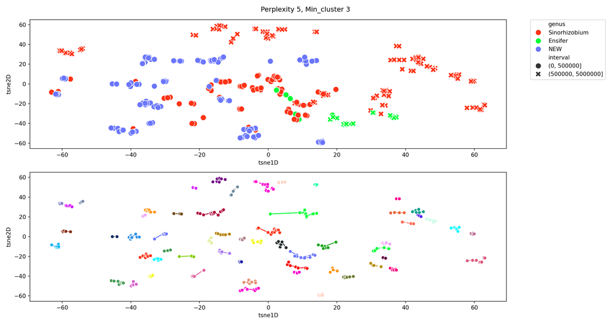

```python
fig,ax=plt.subplots(2,1, figsize=(15,8))
df=mge_all_trial_df.set_index(["perplexity","min_cluster"])
df=df.loc[("5","3")]

# Remove unclassified
df=df[df["Standard_Cluster"] != "-1"]

sns.scatterplot(df, x="tsne1D", y="tsne2D",
                hue="genus",
                style="interval",
                s=100,
                palette=px.colors.qualitative.Light24 + px.colors.qualitative.Dark24,
                legend=True,
                ax=ax[0]
                )

sns.lineplot(df, x="tsne1D", y="tsne2D",
                hue="Standard_Cluster",
                style="interval",
                markers='o',
                palette=px.colors.qualitative.Light24 + px.colors.qualitative.Dark24,
                legend=False,
                ax=ax[1]
                )


plt.suptitle(f"Perplexity 5, Min_cluster 3")

ax[0].legend(bbox_to_anchor=(1.05, 1), loc='upper left', borderaxespad=0)

plt.tight_layout()
plt.show()
```

### After New plasmids (redundant)

Clustering Sinorhizobium plasmids from the PLSDB and **all** the **putative** new plasmids from collaborator data included.

- Top graph presents the clusters colored by Genus, where **NEW** represents Penn State collaborator data.
- Bottom graph represents the clusters colored by the unique clusters established by MGE-Cluster. Colors might be repeated due to the amount of clusters.

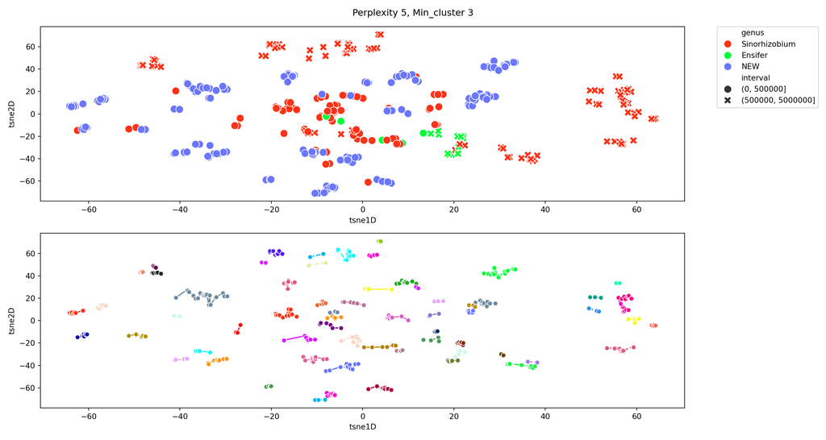

```python
from utils import parse_single_mge_output

perplexity=5
min_cluster=3
mge_output_to_parse=f"/n/projects/jp2992/MOLNG4331/plasmids_smeliloti/plasmidome/clustering_collab_pls_w_sinorhizobium_plsdb/mge_out_{perplexity}_{min_cluster}/{perplexity}_{min_cluster}_model_results.csv"

custom_metadata="Yes"
mge_one_trial_df=parse_single_mge_output(mge_output_to_parse,perplexity,min_cluster,custom_metadata)

# Scatter Plot
fig,ax=plt.subplots(2,1, figsize=(15,8))
df=mge_one_trial_df.set_index(["perplexity","min_cluster"])

df=df.loc[("5","3")]

# Remove unclassified
df=df[df["Standard_Cluster"] != "-1"]

sns.scatterplot(df, x="tsne1D", y="tsne2D",
                hue="genus",
                style="interval",
                s=100,
                palette=px.colors.qualitative.Light24 + px.colors.qualitative.Dark24,
                legend=True,
                ax=ax[0]
                )

sns.lineplot(df, x="tsne1D", y="tsne2D",
                hue="Standard_Cluster",
                style="interval",
                markers='o',
                palette=px.colors.qualitative.Light24 + px.colors.qualitative.Dark24,
                legend=False,
                ax=ax[1]
                )


plt.suptitle(f"Perplexity 5, Min_cluster 3")

ax[0].legend(bbox_to_anchor=(1.05, 1), loc='upper left', borderaxespad=0)

plt.tight_layout()
plt.show()
```

## Number of MPF

The plasmids typing was done with MOB-Typer on the non-redundant dataset from the Collaborator at Penn State University.

```r
df=readr::read_tsv("/n/projects/jp2992/MOLNG4331/collaborator_Smeliloti_hifi/rfplasmid_pred_flye/pred_nonredundant_pls_mobtyper_results.tsv")

number_pls_MPF <- paste0("Number of plasmids with MPF: ", nrow(df[df$mpf_type != "-",]))
print_color(number_pls_MPF, color = "blue")
```

```
## Number of plasmids with MPF: 100
```